# Project_2C

Davide Bottoli, Karolina Gajewska, Przemysław Dycha

13 June 2016

# Introduction

The main goal of this project was finding and presenting the predictions for number of cancer cases in different regions of Poland.

In order to describe new cases of cancer, we chose the following independent variables informed about:

- emission of air pollutants-gases (mainly nitrogen oxides)
- population by gender
- population by gender and age group
- unemployment rate
- population destiny
- salary

We use the same methodology as here [(Phase 2 Project 2)] (https://rawgit.com/pbiecek/StatystykaII/master/MIMUW_2016/projekty/projekt2/phase2/BDG/P2P2_ACT_CV.html)

# Linear Analysis

## Linear Regression

The results obtained by simple linear model are the following:

```
##
## Call:
## lm(formula = new ~ ., data = data_model1)
##
## Residuals:
##      Min       1Q   Median       3Q      Max
## -203.108   -2.649   -0.170    2.206  195.793
##
## Coefficients:
##                           Estimate Std. Error t value Pr(>|t|)
## (Intercept)             -1.882e+02  2.487e+02  -0.757  0.44920
## GENDERM                 -5.739e+00  3.248e-01 -17.669  < 2e-16 ***
## AGE_GROUP<45-54>         3.803e+00  4.104e-01   9.267  < 2e-16 ***
## AGE_GROUP<55-64>         8.413e+00  3.983e-01  21.122  < 2e-16 ***
## AGE_GROUP<65-74>         2.749e+00  4.159e-01   6.610 4.11e-11 ***
## AGE_GROUP<75-84>        -5.659e-01  4.271e-01  -1.325  0.18520
## AGE_GROUP85+            -7.150e+00  4.947e-01 -14.454  < 2e-16 ***
## regionKuyavia-Pomerania  1.159e-01  5.729e-01   0.202  0.83971
## regionLublin            -9.927e-01  5.599e-01  -1.773  0.07626 .
## regionLubusz            -1.200e-01  6.582e-01  -0.182  0.85532
## regionLodz               5.754e-01  5.554e-01   1.036  0.30025
## regionLesser Poland     -1.530e+00  5.660e-01  -2.704  0.00687 **
## regionMazovia           -4.933e-01  4.792e-01  -1.029  0.30328
## regionOpole             -6.740e-01  6.973e-01  -0.966  0.33383
## regionSubcarpathia      -1.238e+00  5.476e-01  -2.261  0.02380 *
## regionPodlaskie         -7.908e-01  6.203e-01  -1.275  0.20244
## regionPomerania          5.966e-01  5.622e-01   1.061  0.28863
## regionSilesia            1.026e-01  5.035e-01   0.204  0.83847
## regionHoly Cross        -5.265e-01  6.440e-01  -0.818  0.41367
## regionWarmia-Masuria     1.427e-01  5.932e-01   0.240  0.80998
## regionGreater Poland     3.762e-01  5.268e-01   0.714  0.47517
## regionWest Pomerania     6.929e-01  5.749e-01   1.205  0.22812
## year                     9.216e-02  1.237e-01   0.745  0.45625
## Population              -6.175e-04  9.104e-06 -67.821  < 2e-16 ***
## Gender_population        1.362e-03  1.812e-05  75.208  < 2e-16 ***
## Population_per_group    -7.107e-05  8.718e-06  -8.152 4.19e-16 ***
## Population.density       5.691e-04  1.851e-04   3.074  0.00212 **
## Salary                   4.919e-04  2.760e-04   1.782  0.07476 .
## Unemployment_rate        5.828e-03  2.189e-02   0.266  0.79008
## NO_industral_plants      2.806e-05  3.852e-05   0.728  0.46633
## ---
## Signif. codes:  0 '***' 0.001 '**' 0.01 '*' 0.05 '.' 0.1 ' ' 1
##
## Residual standard error: 8.607 on 7209 degrees of freedom
## Multiple R-squared:  0.7217, Adjusted R-squared:  0.7206
## F-statistic: 644.8 on 29 and 7209 DF,  p-value: < 2.2e-16
```

# MOVING BEYOND LINEARITY

## Regression trees

With cross validation, we see that the deviance is minimized with a number of leaves equal to 12, so we don’t have the necessity to prune the original tree. As we see from the summary and the plot, the variables used by this model are only Genderpopulation , Population per group, Gender, Age group.

```
##
## Regression tree:
## tree(formula = new ~ ., data = data_model1)
## Variables actually used in tree construction:
## [1] "Gender_population"    "Population_per_group" "GENDER"
## [4] "AGE_GROUP"
## Number of terminal nodes:  12
## Residual mean deviance:  44.62 = 322500 / 7227
## Distribution of residuals:
##      Min.   1st Qu.    Median      Mean   3rd Qu.      Max.
## -199.7000   -2.3200   -0.3202    0.0000    1.6800   98.1700
```

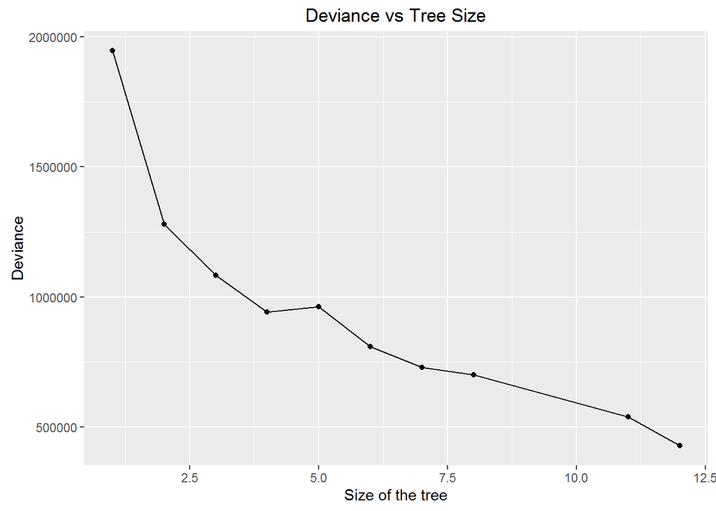

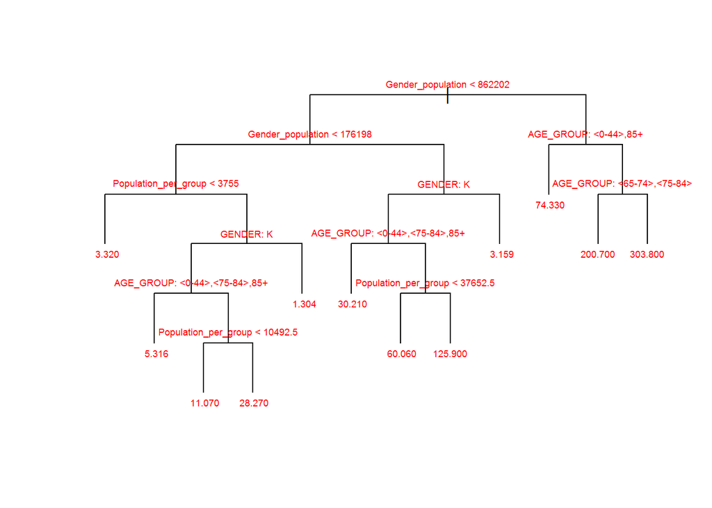